# Who Sets the Rules of Trade?

Stephen Weymouth

Dean’s Professor

2026-08-31

## Bernstein and Keay address different questions

### August 31 · Bernstein

How are trade rules created, contested, evaded, and changed?

Restricted access · illicit commerce · domestic conflict · coercion

### September 2 · Keay

What kind of organization made this trade possible?

Risk · chartered monopoly · armed commerce · delegated authority

Today we study political conflict over trade. Wednesday we dive into corporate power.

# A Brief Writing Exercise

## Your IB Voice

Question

Britain and China had traded at Canton for over a century without war. In 1839 they went to war. What changed? Defend your answer with evidence from the reading.

**10 minutes** · Individual · Notes allowed · No internet or LLMs

## Hypotheses

What explains the war?

Take each one: was it also true in 1780?

# China: Sovereignty and Controlled Trade

## Canton permitted trade on Qing terms

[figure not shown]

The Qing state confined Western foreign trade to Canton and licensed Chinese *hongs* (merchant houses).

The aim was to keep silver at home and foreign influence out.

Qing authorities used the Canton system to control the terms of foreign trade.

William Daniell, *View of the Canton Factories*, 1805–06 · Wikimedia Commons, public domain

## Britain paid for tea with silver

≈90%

of the value Britain sent to China was bullion

In 1751, Britain sent £119,000 in silver and £10,842 in merchandise.

Britain bought tea and silk. China bought little that Britain made.

The imbalance created pressure to find something China would buy.

## Mercantilism linked commerce to national power

**State power:** Commerce should strengthen the state

**Bullion:** Gold and silver supported public credit, military spending, and political power

**Trade balance:** Export surpluses brought bullion into the country

**Empire:** Colonies and chartered companies like EIC secured supplies, markets, shipping

Britain bought Chinese goods with silver while China bought little British merchandise. Mercantilists saw the outflow as a loss of national wealth and power.

## From cotton to opium

[figure not shown]

The EIC grew and auctioned opium in India. Private traders carried it into China.

The increased imports led to silver outflows from China, which they tried to halt

Opium factory at Patna, c. 1851 · Wikimedia Commons, public domain

## Barriers created rents and rewarded evasion

[figure not shown]

Regulation redirected commerce through smugglers and intermediaries.

## Production and finance kept the EIC at the center

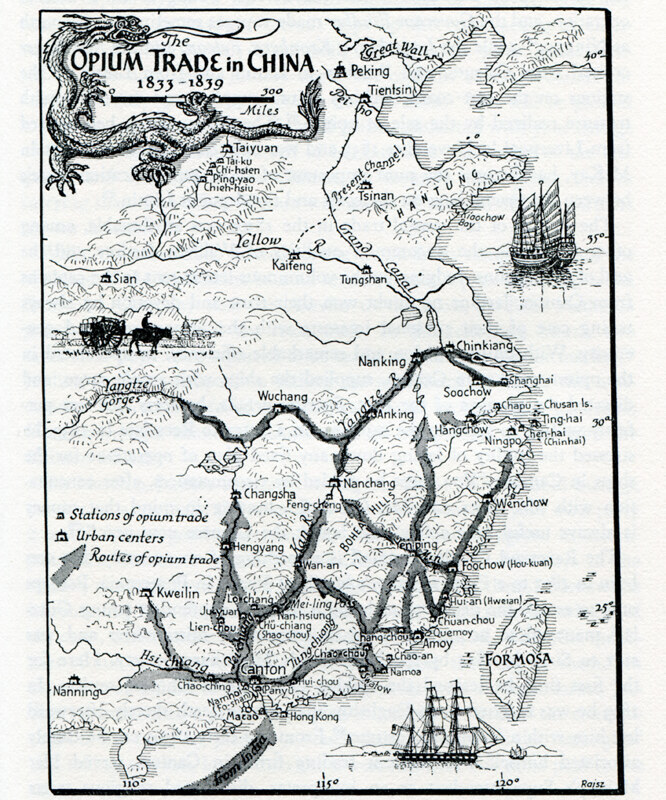

The Company auctioned opium in India.

Private traders sold it in China for silver.

The silver bought Company bills.

EIC silver bought tea.

Infrastructural power: the EIC never carried opium into China, yet every stage of the trade ran through it.

*The Opium Trade in China, 1833–1839* · MIT Visualizing Cultures

## Lin Zexu turned tension into crisis

40,000

chests of opium a year by the late 1830s, four times the 1825 level

In 1839, Commissioner Lin detained foreign merchants and destroyed more than 20,000 chests of opium.

To the Qing court, this was enforcement of Chinese law and sovereignty.

To British merchants, it was an attack on property and commerce.

## Commercial interests mobilized military power

[figure not shown]

Merchants lobbied London for compensation and wider access. The government sent warships.

Britain’s use of military force to expand market access led to interstate conflict: the Opium War.

E. Duncan, *The Nemesis Destroying Chinese War Junks*, 1843 · National Maritime Museum / MIT Visualizing Cultures

## The Treaty of Nanking rewrote the rules of trade

[figure not shown]

Indemnity · Hong Kong · five treaty ports · end of the *hong* monopoly · (eventually) low tariffs

John Platt and John Burnet, *The Signing of the Treaty of Nanking*, 1846 · Anne S. K. Brown Military Collection / Wikimedia Commons, public domain

## The Long Path to More Open Trade

[figure not shown]

Sovereignty → trade restrictions → rents → circumvention

Crackdown → interstate conflict → forced rule change

Responses to the trade imbalance transformed commercial tensions into interstate conflict.

# The Politics of Free Trade in Britain

## What did the Corn Laws actually do?

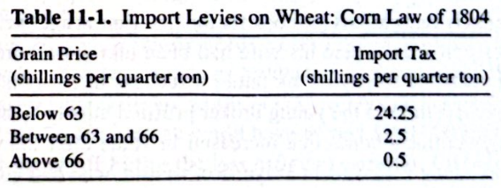

Who is protected when wheat prices fall below 63 shillings? Who pays?

Bernstein, *A Splendid Exchange*, Chapter 11, Table 11-1

## Free-trade ideas became a political program

[figure not shown]

Smith and Ricardo showed that protection raised costs and blocked gains from trade. Cobden’s League organized that argument into a campaign for repeal.

The League turned an abstract economic argument into policy.

## Prepare a 30-second statement for the public hearing

[figure not shown]

**5 minutes** · Individual · Notes permitted

Maintain, modify, or repeal? Consider your two strongest arguments, who gains and who loses, and the strongest argument against your position.

## Public hearing

Should Britain maintain, modify, or repeal the Corn Laws?

We will hear from each side. Listen for interests, expected winners and losers, political influence, and ideas.

# 1845: The potato crop fails. Ireland faces catastrophe.

## Round 2

Does the shock change your position?

If yes, what changed in your reasoning? If no, how do you defend the existing policy now?

**2 minutes** · Individual reconsideration

## The famine raised the political cost of protection

[figure not shown]

Landowners gained from protection and dominated Parliament. But repeal was a known possibility already circulating in political debate.

The crisis fractured the governing coalition and made repeal possible.

## Two pathways made trade rules unstable

### China

Restrictions  
→ circumvention  
→ crackdown  
→ interstate conflict  
→ forced rule change

### Corn Laws

Distributional conflict  
→ durable coalition  
→ external shock  
→ political realignment  
→ liberalization

Rules create rents, coalitions defend them, institutions sustain them, and ideas plus shocks change them.

## The same mechanisms shape international business today

| 18th and 19th Centuries | International business today |
| --- | --- |
| Mercantilism and controlled access | Economic security and strategic sovereignty |
| Smuggling and intermediaries | Transshipment and sanctions evasion |
| EIC production and financial infrastructure | Big Tech dominance |
| Corn Law coalition and famine | Sectoral lobbying and crisis-driven realignment |

When states constrain globalization, firms reorganize trade around the new limits.

## The EIC puzzle remains

What kind of company could organize trade, finance, coercion, and political authority across continents?

On Wednesday we ask why long-distance trade required a chartered company and how that company acquired such immense power.